# Healthcare Project 1

2024-10-09

```r
# Load necessary libraries
library(forecast)
```

```r
library(ggplot2)
library(tseries)
library(readr)
library(lubridate)
library(tidyverse)
# Load the dataset (assuming you have saved PatientVolume.csv file)
data <- read_csv("PatientVolume.csv")
```

```
## ──────────────────────────────────────────────────────── Delimiter: "," chr
## (2): Date, WeekDay dbl (3): ...1, Hour, PatientVolume
```

```r
# Convert the Date column to Date type
data$Date <- as.Date(data$Date, format = "%m/%d/%Y")
data$WeekDay <- as.factor(data$WeekDay)
# Create dummy variables for 'WeekDay'
weekday_dummies <- model.matrix(~ WeekDay - 1, data = data)
# Convert the resulting matrix to a dataframe for easier manipulation
weekday_dummies_df <- as.data.frame(weekday_dummies)
# Drop one of the dummy columns to prevent perfect multicollinearity
weekday_dummies_df <- weekday_dummies_df %>% select(-WeekDayMon)
# Combine dummy variables with the original 'Data' dataframe
data <- cbind(data, weekday_dummies_df)
```

```r
library(magick)
```

```r
img <- image_read("~/Desktop/Healthcare/Project/Project 1/illustration.JPG")
print("See the following graph for reference of our predicted patient volumes for each shift and calculation of MAD for each model:")
```

```
## [1] "See the following graph for reference of our predicted patient volumes for each shift and calculation of MAD for each model:"
```

```r
print(img)
```

```
## # A tibble: 1 × 7
##   format width height colorspace matte filesize density
##   <chr>  <int>  <int> <chr>      <lgl>    <int> <chr>
## 1 JPEG    2244   2904 sRGB       FALSE   488424 72x72
```

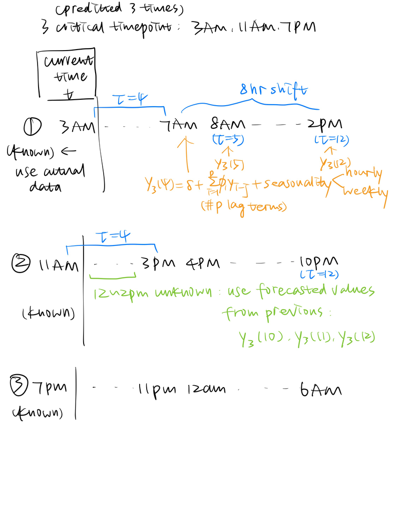

```r
# Splitting the dataset into training and testing datasets based on different periods
# Using the Date column to filter data for different training periods
end_date_6_months <- min(data$Date) + months(6)
end_date_1_year <- min(data$Date) + years(1)
end_date_18_months <- min(data$Date) + months(18)
end_date_2_years <- min(data$Date) + years(2)

train_6_months <- data %>% filter(Date <= end_date_6_months)
train_1_year <- data %>% filter(Date <= end_date_1_year)
train_18_months <- data %>% filter(Date <= end_date_18_months)
train_2_years <- data %>% filter(Date <= end_date_2_years)

test_data_6_months <- data %>% filter(Date > end_date_6_months)
test_data_1_year <- data %>% filter(Date > end_date_1_year)
test_data_18_months <- data %>% filter(Date > end_date_18_months)
test_data_2_years <- data %>% filter(Date > end_date_2_years)

# Convert training and testing data to time series format
train_6_months_ts <- ts(train_6_months$PatientVolume, frequency = 24)
train_1_year_ts <- ts(train_1_year$PatientVolume, frequency = 24)
train_18_months_ts <- ts(train_18_months$PatientVolume, frequency = 24)
train_2_years_ts <- ts(train_2_years$PatientVolume, frequency = 24)

test_data_6_months_ts <- ts(test_data_6_months$PatientVolume, frequency = 24)
test_data_1_year_ts <- ts(test_data_1_year$PatientVolume, frequency = 24)
test_data_18_months_ts <- ts(test_data_18_months$PatientVolume, frequency = 24)
test_data_2_years_ts <- ts(test_data_2_years$PatientVolume, frequency = 24)

# Seasonal dummy
# Extract dummy variables for training periods
xreg_6_months <- train_6_months[, colnames(weekday_dummies_df)]
xreg_1_year <- train_1_year[, colnames(weekday_dummies_df)]
xreg_18_months <- train_18_months[, colnames(weekday_dummies_df)]
xreg_2_years <- train_2_years[, colnames(weekday_dummies_df)]
# Extract corresponding dummy variables for the test periods
test_xreg_6_months <- test_data_6_months[, colnames(weekday_dummies_df)]
test_xreg_1_year <- test_data_1_year[, colnames(weekday_dummies_df)]
test_xreg_18_months <- test_data_18_months[, colnames(weekday_dummies_df)]
test_xreg_2_years <- test_data_2_years[, colnames(weekday_dummies_df)]
# seasonal_ind1 = seasonaldummy(train_6_months_ts)
# seasonal_ind2 = seasonaldummy(train_6_months_ts)
# seasonal_ind3 = seasonaldummy(train_6_months_ts)
# seasonal_ind4 = seasonaldummy(train_6_months_ts)

# Train ARIMA models using different training periods
models <- list(
  arima_6_months = auto.arima(train_6_months_ts, xreg = as.matrix(xreg_6_months)),
  # Uncomment below to train additional models with respective dummy variables
  arima_1_year = auto.arima(train_1_year_ts, xreg = as.matrix(xreg_1_year)),
  arima_18_months = auto.arima(train_18_months_ts, xreg = as.matrix(xreg_18_months)),
  arima_2_years = auto.arima(train_2_years_ts, xreg = as.matrix(xreg_2_years))
)

# Function to calculate MAD
mad_metric <- function(actual, predicted) {
  return(mean(abs(actual - predicted)))
}
# Predict patient volumes for each shift and calculate MAD for each model
mad_values <- c()

for (model_name in names(models)) {
  model <- models[[model_name]]

  # Extract appropriate test data and corresponding xreg based on model name
  if (model_name == "arima_6_months") {
    actual_test_ts <- test_data_6_months_ts
    test_xreg <- test_xreg_6_months
  } else if (model_name == "arima_1_year") {
    actual_test_ts <- test_data_1_year_ts
    test_xreg <- test_xreg_1_year
  } else if (model_name == "arima_18_months") {
    actual_test_ts <- test_data_18_months_ts
    test_xreg <- test_xreg_18_months
  } else if (model_name == "arima_2_years") {
    actual_test_ts <- test_data_2_years_ts
    test_xreg <- test_xreg_2_years
  }

  # Predict for 7:00AM to 2:00PM (at 3:00AM)
  actual_7am_shift <- window(actual_test_ts, start = 7, end = 14)  # Extract actual values for 7AM to 2PM shift
  h_pred_7am <- length(actual_7am_shift)  # Set prediction horizon to match the actual data length
  pred_7am_shift <- ts(forecast(model, xreg = as.matrix(test_xreg[1:h_pred_7am, ]), h = h_pred_7am)$mean,
                       start = start(actual_7am_shift), frequency = frequency(actual_7am_shift))  # Forecast with `xreg`
  mad_7am <- mad_metric(actual_7am_shift, pred_7am_shift)

  # Predict for 3:00PM to 10:00PM (at 11:00AM)
  extended_train_3pm <- c(train_6_months_ts, pred_7am_shift) # Extend training data with predictions from 7AM shift
  model_extended_3pm <- Arima(extended_train_3pm, model = model, xreg = as.matrix(rbind(xreg_6_months, test_xreg[1:h_pred_7am, ]))) # Refit with extended data and exogenous variables
  actual_3pm_shift <- window(actual_test_ts, start = 15, end = 22)  # Extract actual values for 3PM to 10PM shift
  h_pred_3pm <- length(actual_3pm_shift)  # Set prediction horizon to match the actual data length
  pred_3pm_shift <- ts(forecast(model_extended_3pm, xreg = as.matrix(test_xreg[(h_pred_7am + 1):(h_pred_7am + h_pred_3pm), ]), h = h_pred_3pm)$mean,
                       start = start(actual_3pm_shift), frequency = frequency(actual_3pm_shift))
  mad_3pm <- mad_metric(actual_3pm_shift, pred_3pm_shift)

  # Predict for 11:00PM to 6:00AM (at 7:00PM)
  extended_train_11pm <- c(train_6_months_ts, pred_7am_shift, pred_3pm_shift) # Extend training data with previous predictions
  model_extended_11pm <- Arima(extended_train_11pm, model = model, xreg = as.matrix(rbind(xreg_6_months, test_xreg[1:(h_pred_7am + h_pred_3pm), ]))) # Refit with extended data and exogenous variables
  actual_11pm_shift <- window(actual_test_ts, start = 23, end = 30)  # Extract actual values for 11PM to 6AM shift
  h_pred_11pm <- length(actual_11pm_shift)  # Set prediction horizon to match the actual data length
  pred_11pm_shift <- ts(forecast(model_extended_11pm, xreg = as.matrix(test_xreg[(h_pred_7am + h_pred_3pm + 1):(h_pred_7am + h_pred_3pm + h_pred_11pm), ]), h = h_pred_11pm)$mean,
                        start = start(actual_11pm_shift), frequency = frequency(actual_11pm_shift))
  mad_11pm <- mad_metric(actual_11pm_shift, pred_11pm_shift)

  # Calculate average MAD for all shifts
  avg_mad <- mean(c(mad_7am, mad_3pm, mad_11pm))
  mad_values <- c(mad_values, avg_mad)
}

##########

# Assign names to MAD values
names(mad_values) <- names(models)
print(mad_values)
```

```
##  arima_6_months    arima_1_year arima_18_months   arima_2_years
##        6.950823        7.791395        7.980774        5.866665
```

```r
print(models)
```

```
## $arima_6_months
## Series: train_6_months_ts
## Regression with ARIMA(5,0,0)(2,1,0)[24] errors
##
## Coefficients:
##          ar1     ar2     ar3     ar4      ar5     sar1     sar2  WeekDayFri
##       0.6257  0.1273  0.0855  0.0219  -0.0220  -0.6660  -0.3418     -8.6564
## s.e.  0.0139  0.0190  0.0183  0.0180   0.0164   0.0143   0.0154      0.6231
##       WeekDaySat  WeekDaySun  WeekDayThu  WeekDayTue  WeekDayWed
##         -15.2572     -9.6554     -6.1685      3.3032     -4.2477
## s.e.      0.6180      0.5372      0.6265      0.5355      0.6185
##
## sigma^2 = 16.72:  log likelihood = -12282.06
## AIC=24592.11   AICc=24592.21   BIC=24681.39
##
## $arima_1_year
## Series: train_1_year_ts
## Regression with ARIMA(5,0,0)(2,1,0)[24] errors
##
## Coefficients:
##          ar1     ar2     ar3     ar4      ar5     sar1     sar2  WeekDayFri
##       0.6360  0.1201  0.0800  0.0190  -0.0210  -0.6533  -0.3326     -8.4524
## s.e.  0.0106  0.0127  0.0127  0.0129   0.0108   0.0101   0.0100      0.4397
##       WeekDaySat  WeekDaySun  WeekDayThu  WeekDayTue  WeekDayWed
##         -15.2695     -9.3778     -5.5487      3.3753     -3.6538
## s.e.      0.4355      0.3775      0.4395      0.3773      0.4358
##
## sigma^2 = 16.76:  log likelihood = -24778.34
## AIC=49584.68   AICc=49584.72   BIC=49683.77
##
## $arima_18_months
## Series: train_18_months_ts
## Regression with ARIMA(5,0,0)(2,1,0)[24] errors
##
## Coefficients:
##          ar1     ar2     ar3     ar4      ar5     sar1     sar2  WeekDayFri
##       0.6389  0.1269  0.0744  0.0167  -0.0161  -0.6610  -0.3388     -8.3337
## s.e.  0.0138  0.0107  0.0131  0.0144   0.0107   0.0084   0.0095      0.3601
##       WeekDaySat  WeekDaySun  WeekDayThu  WeekDayTue  WeekDayWed
##         -15.0070     -9.2805     -5.9739      3.1430     -3.8920
## s.e.      0.3555      0.3073      0.3605      0.3075      0.3561
##
## sigma^2 = 16.37:  log likelihood = -36908.41
## AIC=73844.82   AICc=73844.85   BIC=73949.55
##
## $arima_2_years
## Series: train_2_years_ts
## Regression with ARIMA(4,0,1)(2,1,0)[24] errors
##
## Coefficients:
##          ar1     ar2     ar3     ar4     ma1     sar1     sar2  WeekDayFri
##       0.2359  0.3827  0.1242  0.0400  0.4048  -0.6624  -0.3406     -8.4507
## s.e.  0.2200  0.1347  0.0248  0.0179  0.2248   0.0400   0.0140      0.3123
##       WeekDaySat  WeekDaySun  WeekDayThu  WeekDayTue  WeekDayWed
##         -15.1009     -9.2702     -5.7775      3.0089     -3.9943
## s.e.      0.3081      0.2665      0.3118      0.2661      0.3083
##
## sigma^2 = 16.27:  log likelihood = -49292.95
## AIC=98613.9   AICc=98613.93   BIC=98722.7
```

From the above results, we can see the model that has the smallest MAD error is the one using arima_2_years as training data set. It is with an ARIMA component using the ARIMA(4,0,1)(2,1,0) model. This model includes autoregressive (AR) terms, a moving average (MA) term, and seasonal autoregressive (SAR) terms, along with regressors for day-of-the-week effects.

Model Interpretation:

- **Autoregressive (AR) Terms**: The coefficients for AR(1), AR(2), AR(3), and AR(4) suggest that the model is using four previous time steps to predict the current value. The largest impact comes from AR(2) with a value of $\phi_2 = 0.3827$.
- **Moving Average (MA) Term**: The MA(1) coefficient, $\theta_1 = 0.4048$, represents the influence of the previous error on the current forecast.
- **Seasonal Autoregressive (SAR) Terms**: The SAR(1) and SAR(2) terms capture seasonal patterns over a longer period. The negative values for $\Phi_1 = -0.6624$ and $\Phi_2 = -0.3406$ indicate that seasonality has an inverse impact over time.
- **Day-of-the-Week Regressors**: The weekday dummy variables show the effect of each day of the week on the forecast. For example:
  - Fridays ($\text{WeekDayFri} = -8.4507$) and Saturdays ($\text{WeekDaySat} = -15.1009$) have a significant negative effect on the predicted values.
  - Tuesdays ($\text{WeekDayTue} = 3.0089$) have a positive effect, while other weekdays (like Wednesday, Thursday, and Sunday) have varying levels of negative effects.

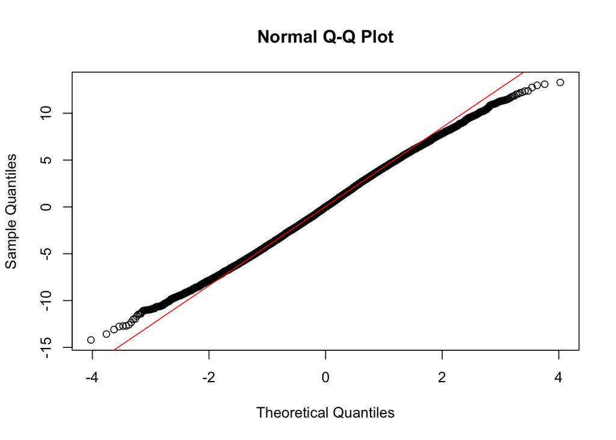

```r
# Selecting the best model based on the lowest MAD
best_model_name <- names(which.min(mad_values))
best_model <- models[[best_model_name]]

# Plotting the residuals and Q-Q plot for the best model
residuals_best_model <- residuals(best_model)

# Q-Q plot to check normality
qqnorm(residuals_best_model)
qqline(residuals_best_model, col = "red")
```

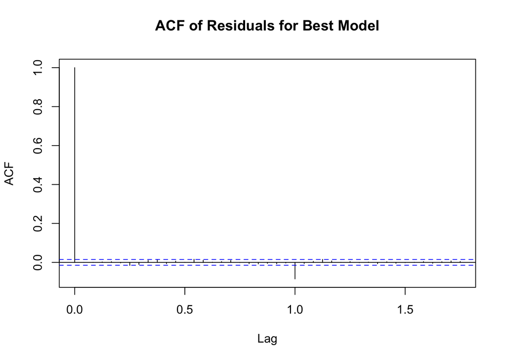

```r
# Plot ACF of residuals
acf(residuals_best_model, main = "ACF of Residuals for Best Model")
```

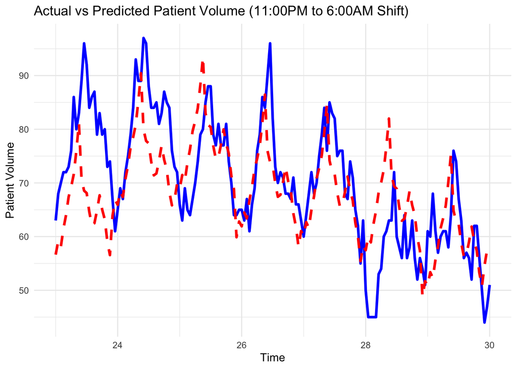

```r
# Plotting combined actual and predicted values for 11:00PM to 6:00AM shift
combined_ts <- ts(c(actual_11pm_shift, pred_11pm_shift), frequency = 8)
time_index <- time(actual_11pm_shift)
forecast_index <- time(pred_11pm_shift)

ggplot() +
  geom_line(aes(x = time_index, y = as.numeric(actual_11pm_shift)), color = "blue", size = 1.2) +
  geom_line(aes(x = forecast_index, y = as.numeric(pred_11pm_shift)), color = "red", size = 1.2, linetype = "dashed") +
  labs(title = "Actual vs Predicted Patient Volume (11:00PM to 6:00AM Shift)",
       x = "Time",
       y = "Patient Volume") +
  theme_minimal()
```

As for possibility for further improvement in the model, we can tell from the difference between the plotted graph and actual still exists. To improve the ARIMA model after accounting for seasonality of week and day, we can:

1. Incorporate Exogenous Variables (ARIMAX): If external factors influence patient volume, such as holidays, weather conditions, or public health events, you can include these variables in an ARIMAX model. For instance:
- Weather data (e.g., temperature, humidity)
- Holidays or special events
- Staffing levels or schedules
2. Consider non-linear models like SARIMA or TBATS:

SARIMA (Seasonal ARIMA) explicitly models seasonal patterns. TBATS (Trigonometric, Box-Cox, ARMA errors, Trend, and Seasonal) handles complex seasonality and multiple seasonalities better than ARIMA, especially when dealing with multiple seasonal cycles (e.g., daily and weekly).

3. Consider interactions between these terms. There might be interactions between the weekly and daily cycles that the model is not capturing well.
4. Use More Advanced Time Series Models Consider more advanced methods such as: Prophet (Facebook): Automatically detects change points in the trend and handles seasonality well. Long Short-Term Memory (LSTM) or Recurrent Neural Networks (RNN): Deep learning models, particularly LSTM, are capable of capturing long-term dependencies in time series data.